# Final Exam AMA-DS, January 2023. Practice

Pedro Delicado

2023-01-09

# Human Development Index

In the `HDI.Rdata` file you will find some data published by the UNITED NATIONS DEVELOPMENT PROGRAM in its *Human Development Report* corresponding to the year 2017. After reading this file with

```r
load("HDI.Rdata")
```

you will find the *data frame* `HDI` with the following the following variables:

| Variable | Description |
| --- | --- |
| HDI | Human Development Index (HDI) |
| Median_age | Median age (years) |
| Old_age_dep_rat | Old-age (65 and older) dependency ratio (per 100 people ages 15-64) |
| Exp_years_school | Expected years of schooling (years) |
| Life_expec | Life expectancy at birth (years) |
| Inf_Mort_rat | Mortality rate, infant (per 1,000 live births) |
| log_GDP_per_cap | logarithm of the Gross domestic product (GDP) per capita (PPP $: international dollars with purchasing power parity) |
| Mob_phon_100_peopl | Mobile phone subscriptions (per 100 people) |
| Agric_employ_perc | Employment in agriculture (% of total employment) |
| Servi_employ_perc | Employment in services (% of total employment) |
| Employment_rat | Employment to population ratio (% ages 15 and older) |
| Continent | Continent |

The **country names** are the row names of `HDI` and can be recovered by

```r
country <- row.names(HDI)
```

## 1. Dimensionality reduction **(2 points out of 10)**

Let $X$ be the data matrix with columns 2 to 11 of `HDI`:

```r
X <- as.matrix(HDI[,2:11])
```

Do dimensionality reduction of the columns of $X$, from 10 dimesnions to $q=1$, in two different ways:

**1.1** Computing the principal curve (as defined by Hastie and Stuetzle, 1989). Select the tuning parameter by using the local continuity meta criteria (with $K'=5$). Choose `df` in `seq(15,25,by=2)`

**1.2** Performing local MDS. Select the tuning parameters by using the local continuity meta criteria (with $K'=5$). Choose `K` in `seq(3,15,by=2)` and `tau` in `c(.5,1)`.

```r
library(princurve)
library(stops)
```

```r
LCMC <- function(D1,D2,Kp=10){
  D1 <- as.matrix(D1)
  D2 <- as.matrix(D2)
  n <- dim(D1)[1]
  N.Kp.i <- numeric(n)
  for (i in 1:n){
    N1.i <- sort.int(D1[i,],index.return = TRUE)$ix[1:Kp]
    N2.i <- sort.int(D2[i,],index.return = TRUE)$ix[1:Kp]
    N.Kp.i[i] <- length(intersect(N1.i, N2.i))
  }
  N.Kp<-mean(N.Kp.i)
  M.Kp.adj <- N.Kp/Kp - Kp/(n-1)

  return(list(N.Kp.i=N.Kp.i, M.Kp.adj=M.Kp.adj))
}
```

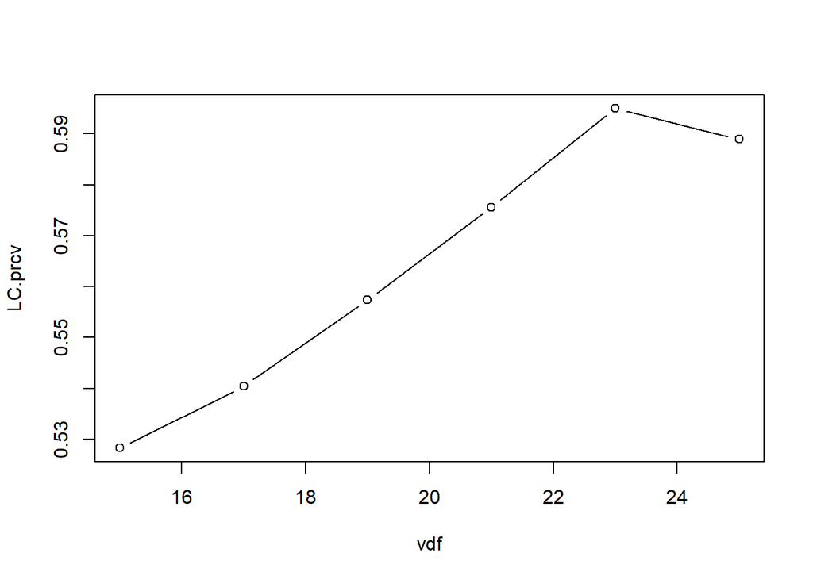

```r
# principal curve
Kp <- 5
DX <- dist(X)

vdf <- seq(15,25,by=2)
LC.prcv <- numeric(length(vdf))

prcv.df <- vector("list",length(LC.prcv))

for (j in 1:length(vdf)){
    #prcv.df[[j]] <- principal_curve(prcomp(HDI[, 2:11])$x, df=vdf[j])
    prcv.df[[j]] <- principal_curve(X, df=vdf[j])
    D2.j <- dist(prcv.df[[j]]$lambda)
    LC.prcv[j] <- LCMC(DX,D2.j,Kp)$M.Kp.adj
}

plot(vdf,LC.prcv,type="b")
```

```r
j.max <- which.max(LC.prcv)
df.max <- vdf[j.max]
PrCv.max <- prcv.df[[j.max]]
print(paste0("df.max=",df.max))
```

```
## [1] "df.max=23"
```

```r
# local MDS
Kp <- 5
# DX <- dist(X)

K <- seq(3,15,by=2)#c(5,10,15)
tau <- c(.5,1)#c(.1,.5,1)
q <- 1
conf0 <- cmdscale(DX, k=q)$points

LC <- matrix(0,nrow=length(K),ncol=length(tau))
lmds.k.tau <- array(vector("list",1),dim=dim(LC))

init.conf <- conf0

for (i in 1:length(K)){
  for (j in 1:length(tau)){
    lmds.k.tau[[i,j]] <- lmds(as.matrix(DX), init=conf0, ndim=q,
                              k=K[i], tau=tau[j], itmax = 100)
    D2.k.tau <- lmds.k.tau[[i,j]]$confdist
    LC[i,j] <- LCMC(DX,D2.k.tau,Kp)$M.Kp.adj
    #print(c(i,j,LC[i,j]))
  }
}

ij.max <- arrayInd(which.max(LC),.dim=dim(LC))
k.max <- K[ij.max[1]]
tau.max <- tau[ij.max[2]]
lmds.max <- lmds.k.tau[[ij.max[1],ij.max[2]]]
lmds.LC.max <- LC[ij.max]

print(paste0("Local MDS: k.max=",k.max,", tau.max=",tau.max, ",LC(k.max,tau.max)=",LC[ij.max]))
```

```
## [1] "Local MDS: k.max=3, tau.max=1,LC(k.max,tau.max)=0.379209164818921"
```

**1.3** Do a *pairs plot* (that is, a matrix of scatterplots) of the matrix having the following 4 columns:

- `HDI$HDI`
- First principal component of $X$
- 1-dimensional configuration obtained by principal curves.
- 1-dimensional configuration obtained by local MDS.

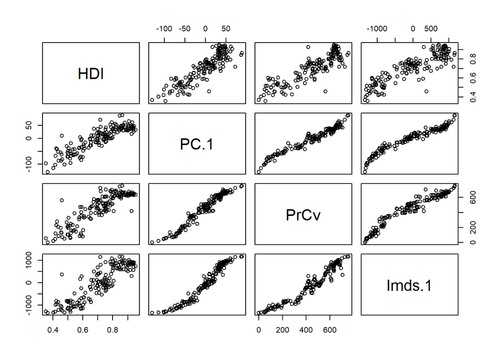

```r
aux <- cbind(HDI$HDI, prcomp(X)$x[,1],PrCv.max$lambda,lmds.max$conf)
colnames(aux) <- c("HDI", "PC.1", "PrCv", "lmds.1")
pairs(aux)
```

**1.4** Comment your results.

```r
# The HDI is defined in such a way it represents a summary of all the
# measurable variables indicating "human development", in some way.
# This objective can also be reached by using any dimensionality reduction
# method, as PC, principal curves or local MDS.
# Then it is natural that these 4 variables are highly correlated.
```

## 2. Nonparametric regression **(2.5 points out of 10)**

**2.1** Do the scatterplot of $y=$`Old_age_dep_rat` against $x=$ `Median_age`. Do yout think there are some countries which could be considered outliers?

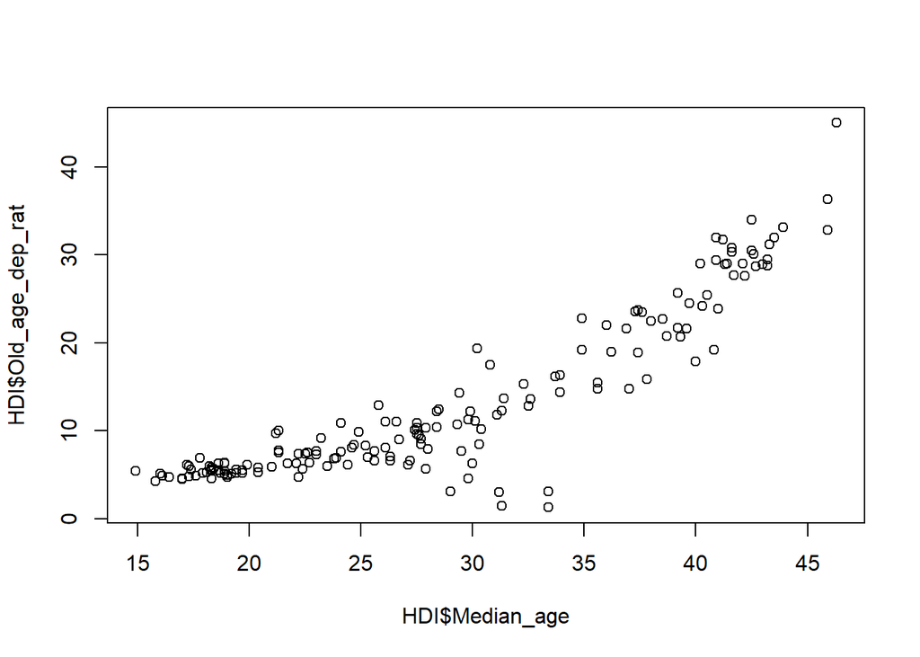

```r
plot(HDI$Median_age,HDI$Old_age_dep_rat)
```

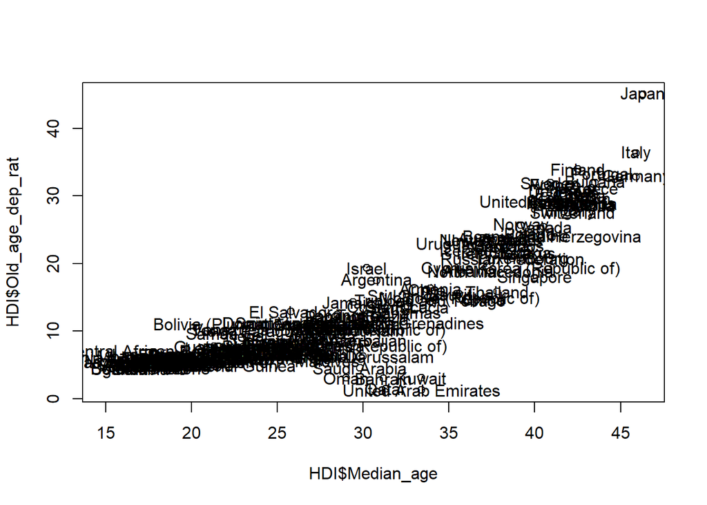

```r
plot(HDI$Median_age,HDI$Old_age_dep_rat)
text(HDI$Median_age,HDI$Old_age_dep_rat,country)
```

**2.2** To identify those possible outliers, fit a simple nonparametric regression model of `Old_age_dep_rat` as a function of `Median_age`. Use smoothing splines with *degrees of freedom* chosen by Generalized Cross Validation.

```r
library(mgcv)
gam1 <- gam(Old_age_dep_rat~s(Median_age),data=HDI)
summary(gam1)
```

```
##
## Family: gaussian
## Link function: identity
##
## Formula:
## Old_age_dep_rat ~ s(Median_age)
##
## Parametric coefficients:
##             Estimate Std. Error t value Pr(>|t|)
## (Intercept)  13.2855     0.2289   58.05   <2e-16 ***
## ---
## Signif. codes:  0 '***' 0.001 '**' 0.01 '*' 0.05 '.' 0.1 ' ' 1
##
## Approximate significance of smooth terms:
##                 edf Ref.df   F p-value
## s(Median_age) 3.708  4.628 325  <2e-16 ***
## ---
## Signif. codes:  0 '***' 0.001 '**' 0.01 '*' 0.05 '.' 0.1 ' ' 1
##
## R-sq.(adj) =  0.902   Deviance explained = 90.4%
## GCV = 8.8961  Scale est. = 8.6422    n = 165
```

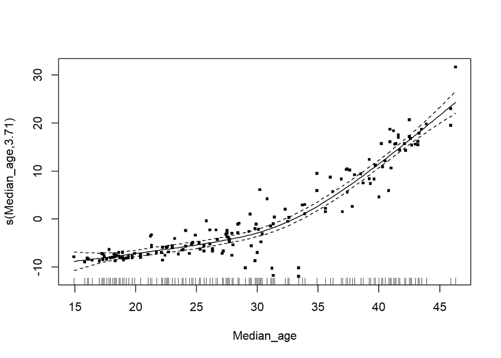

```r
plot(gam1, residuals=TRUE, cex=4)
```

```r
# another alternative: using smooth.spline()
sm.spl.1 <- smooth.spline(HDI$Median_age,HDI$Old_age_dep_rat)
```

**2.3** Once you have fitted this model, which is the estimated value $\hat{\sigma}$ of the residual standard deviation?  
If this estimation is not included in the fitted smoothing spline object, you can compute it from the residuals. If the residuals are not directly available, you can use the functions `fitted` to compute the fitted values of your estimated model and use them to compute residuals.

```r
(sig <- sqrt(gam1$sig2))
```

```
## [1] 2.939767
```

```r
# another alternative: using smooth.spline()
n<- dim(HDI)[1]
fitted_values <- fitted(sm.spl.1)
resids <- HDI$Old_age_dep_rat - fitted_values
(sig_spl <- sqrt(sum(resids^2)/(n-sm.spl.1$df)))
```

```
## [1] 2.938926
```

**2.4** Add to the scatterplot of $y=$`Old_age_dep_rat` against $x=$ `Median_age` the following elements:

- the points with coordinates $x=$ `Median_age` and $y=$ the fitted values.
- the points with coordinates $x=$ `Median_age` and $y=$ the fitted values $+/- 1.96\,\hat{\sigma}$.
- the names of the countries for which the absolute value of the residuals are larger than $1.96\ \hat{\sigma}$. These points are those you can consider outliers.

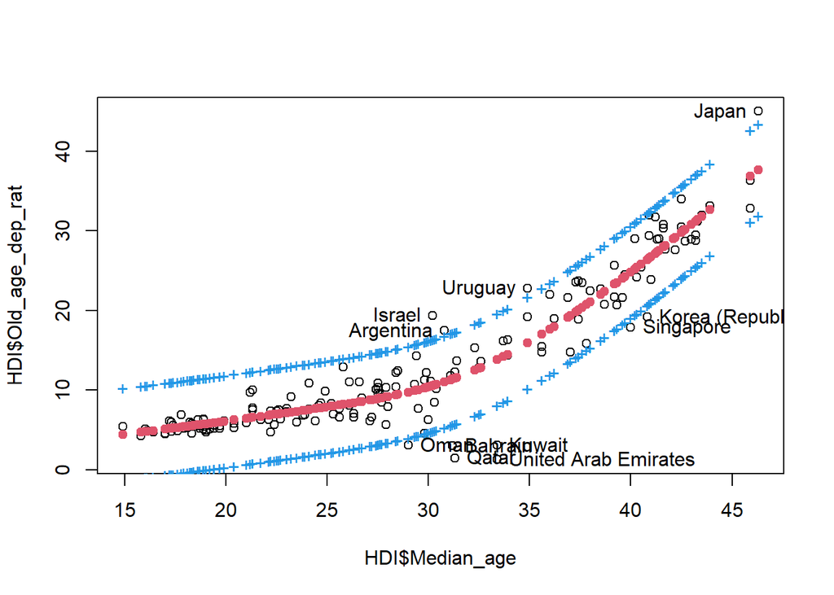

```r
plot(HDI$Median_age,HDI$Old_age_dep_rat)
points(HDI$Median_age,gam1$fitted.values,col=2, pch=19)
points(HDI$Median_age,gam1$fitted.values-1.96*sig,col=4, pch="+")
points(HDI$Median_age,gam1$fitted.values+1.96*sig,col=4, pch="+")
I_res_neg <- which(gam1$fitted.values-1.96*sig>HDI$Old_age_dep_rat)
I_res_pos <- which(gam1$fitted.values+1.96*sig<HDI$Old_age_dep_rat)
text(HDI$Median_age[I_res_neg],HDI$Old_age_dep_rat[I_res_neg],
     country[I_res_neg], pos=4)
text(HDI$Median_age[I_res_pos],HDI$Old_age_dep_rat[I_res_pos],
     country[I_res_pos], pos=2)
```

```r
country[I_res_neg]
```

```
## [1] "United Arab Emirates" "Bahrain"              "Korea (Republic of)"
## [4] "Kuwait"               "Oman"                 "Qatar"
## [7] "Singapore"
```

```r
country[I_res_pos]
```

```
## [1] "Argentina" "Israel"    "Japan"     "Uruguay"
```

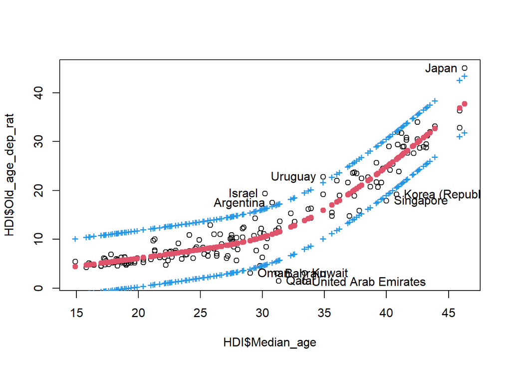

```r
# another alternative: using smooth.spline()
plot(HDI$Median_age,HDI$Old_age_dep_rat)
points(HDI$Median_age,fitted_values,col=2, pch=19)
points(HDI$Median_age,fitted_values-1.96*sig_spl,col=4, pch="+")
points(HDI$Median_age,fitted_values+1.96*sig_spl,col=4, pch="+")
I_res_neg <- which(fitted_values-1.96*sig_spl>HDI$Old_age_dep_rat)
I_res_pos <- which(fitted_values+1.96*sig_spl<HDI$Old_age_dep_rat)
text(HDI$Median_age[I_res_neg],HDI$Old_age_dep_rat[I_res_neg],
     country[I_res_neg], pos=4)
text(HDI$Median_age[I_res_pos],HDI$Old_age_dep_rat[I_res_pos],
     country[I_res_pos], pos=2)
```

```r
country[I_res_neg]
```

```
## [1] "United Arab Emirates" "Bahrain"              "Korea (Republic of)"
## [4] "Kuwait"               "Oman"                 "Qatar"
## [7] "Singapore"
```

```r
country[I_res_pos]
```

```
## [1] "Argentina" "Israel"    "Japan"     "Uruguay"
```

**2.5** Could you provide any explanation why those countries are outliers?

```r
# There are 7 countries with very low "Old age dependence ratio":
## [1] "United Arab Emirates" "Bahrain"              "Korea (Republic of)"
## [4] "Kuwait"               "Oman"                 "Qatar"
## [7] "Singapore"
#
# Five of them are in the Persian Gulf. They are those with lowest median age (around 30 years).
# They are young countries in median with very few old people.
# Probably foreign immigration could explain these facts.
# The other two countries are well developed Asian countries: South Korea and Singapore.
#
# There are 4 countries with unusually high "Old age dependence ratio":
## [1] "Argentina" "Israel"    "Japan"     "Uruguay"
#
# Japan is the most aged country in the data set: a median age over 45 years.
# The other three countries have median age in 30-35 years.
```

## 3. Functional data analysis **(2.5 points out of 10)**

The Rdata file `HDI_series.Rdata` contains the data frame `HDI_series`, with rows corresponding to the 134 countries (the row names of `HDI_series` are the country names). The 32 columns of `HDI_series` correspond to years 1990 to 2021. The entry $(i,j)$ of `HDI_series` is the value of HDI for country $i$ at year $j$.  
*(Note: The source of data of `HDI` and `HDI_series` are different. Then the values of `HDI_series` for year 2017 do not coincide exactly with those of `HDI$HDI`)*

**3.1** Transform the data in `HDI_series` into a functional data set, with countries as individuals and years as argument of the functions:

- First, transform the raw data to a `fdata`object.
- Then, smooth the raw functional data in an optimal way using generalized cross-validation and local linear smoothing.

Call `HDI_LL` to the smoothed functional data.

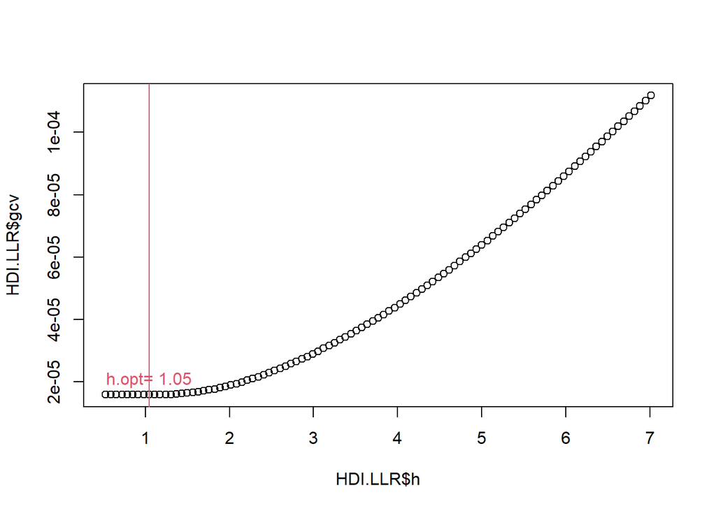

```r
load("HDI_series.Rdata")
library(fda.usc)
years <- 1990:2021
HDI.fdata <- fdata(mdata=as.matrix(HDI_series), argvals = years,
                      rangeval = range(years),
                      names = list(main="HDI 1990-2021",
                                   xlab="Year",ylab="HDI"))

HDI.LLR <- optim.np(HDI.fdata, type.S = S.LLR)

plot(HDI.LLR$h,HDI.LLR$gcv,type="b")
abline(v=HDI.LLR$h.opt,col=2)
text(HDI.LLR$h.opt,min(HDI.LLR$gcv),
      paste("h.opt=",round(HDI.LLR$h.opt,2)),
      pos=3,col=2)
```

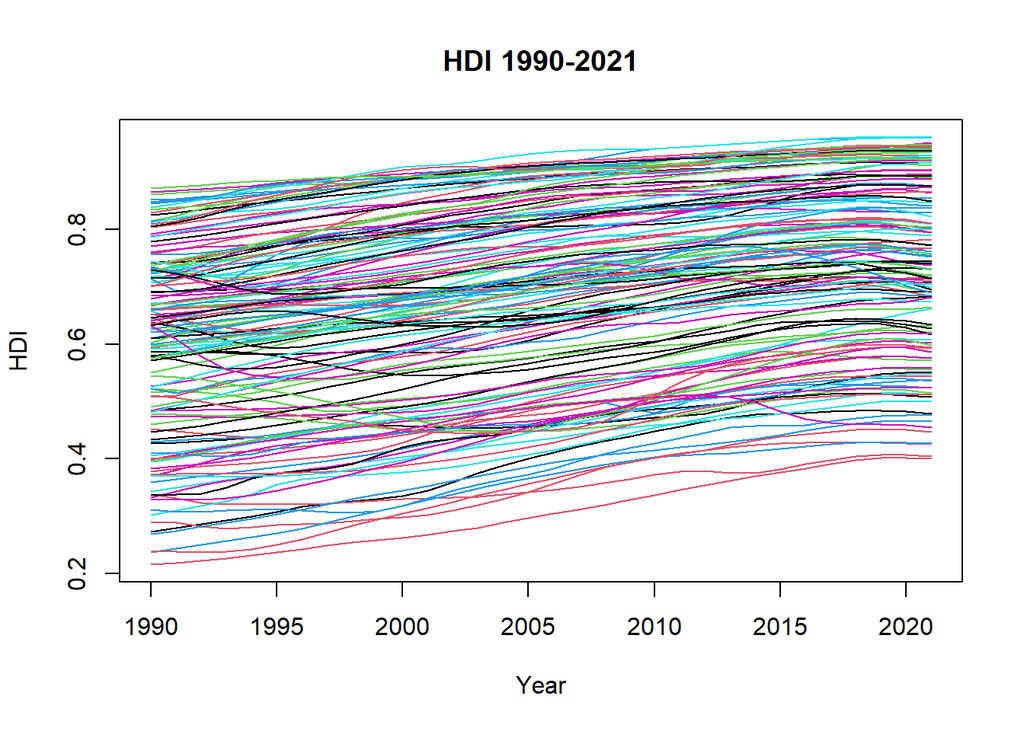

```r
HDI_LL <- HDI.LLR$fdata.est
plot(HDI_LL)
```

**3.2** Do descriptive statistics of `HDI_LL` (mean, median and standard deviation functions).  
*(Note: If you have not found `HDI_LL` then use the raw data functional data set)*

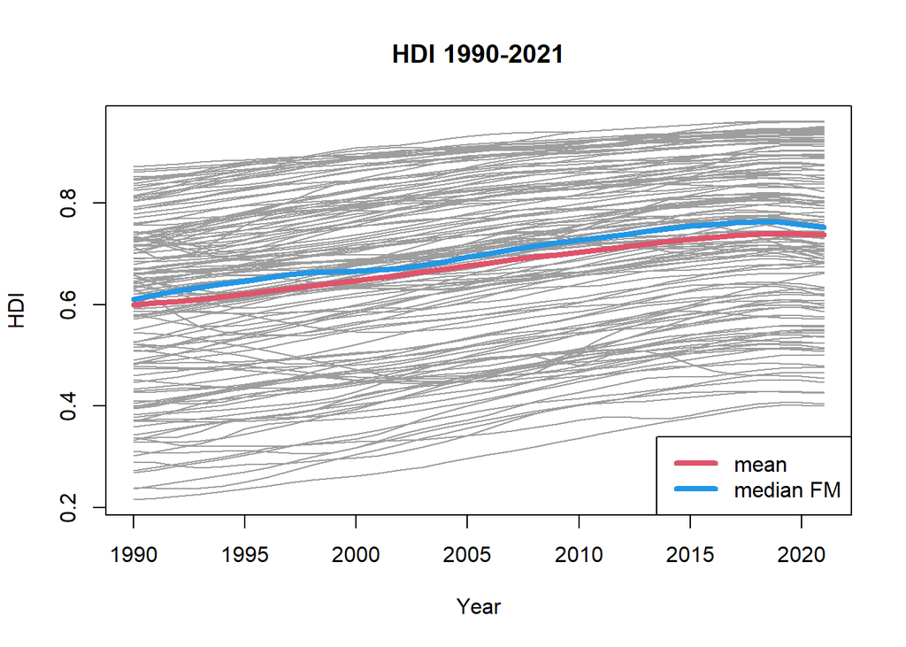

```r
plot(HDI_LL, col=8)
plot(func.mean(HDI_LL),add=TRUE,lwd=4,col=2)
plot(func.med.FM(HDI_LL),add=TRUE,lwd=4,col=4)
legend("bottomright",c("mean","median FM"),lwd=4,col=c(2,4),cex=1)
```

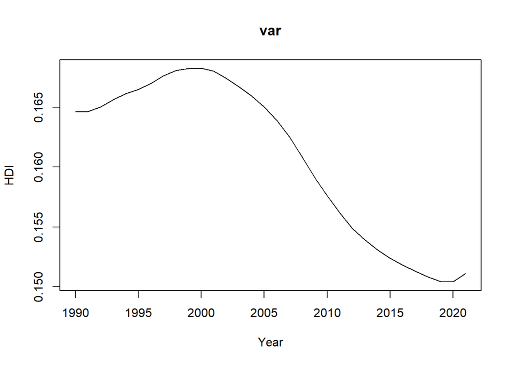

```r
plot(sqrt(func.var(HDI_LL)))
```

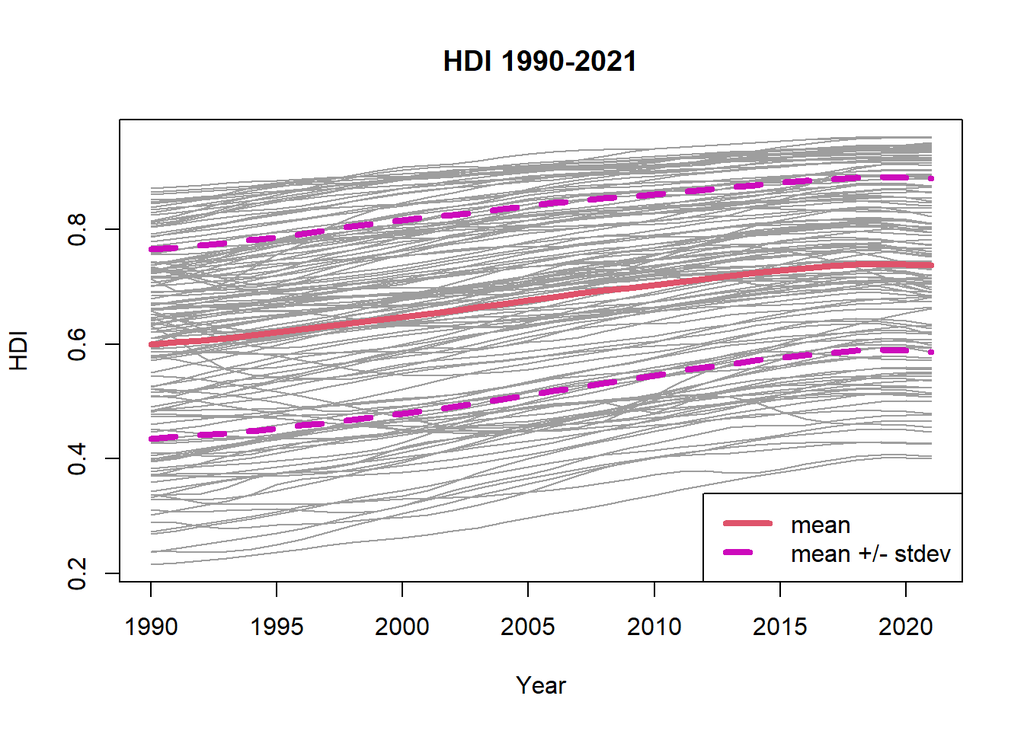

```r
plot(HDI_LL, col=8)
plot(func.mean(HDI_LL),add=TRUE,lwd=4,col=2)
plot(func.mean(HDI_LL)+1*sqrt(func.var(HDI_LL)),add=TRUE,lwd=4,col=6,lty=2)
plot(func.mean(HDI_LL)-1*sqrt(func.var(HDI_LL)),add=TRUE,lwd=4,col=6,lty=2)
legend("bottomright",c("mean","mean +/- stdev"),lwd=4,col=c(2,6), lty=c(1,2),cex=1)
```

**3.3** Look for outliers in the functional data set `HDI_LL`.  
*(Note: If you have not found `HDI_LL` then use the raw data functional data set)*

```r
outl_HDI_LL.mode <- outliers.depth.pond(HDI_LL, nb = 200, dfunc = depth.mode)
outl_HDI_LL.mode$outliers
```

```
## character(0)
```

```r
# No outliers found!
```

```r
outl_HDI_LL.FM <- outliers.depth.pond(HDI_LL, nb = 200, dfunc = depth.FM)
outl_HDI_LL.FM$outliers
```

```
## character(0)
```

```r
# No outliers found!
```

**3.4** Perform Functional PCA on `HDI_LL` and try to give an interpretation of the first two principal functions.  
*(Note: If you have not found `HDI_LL` then use the raw data functional data set)*

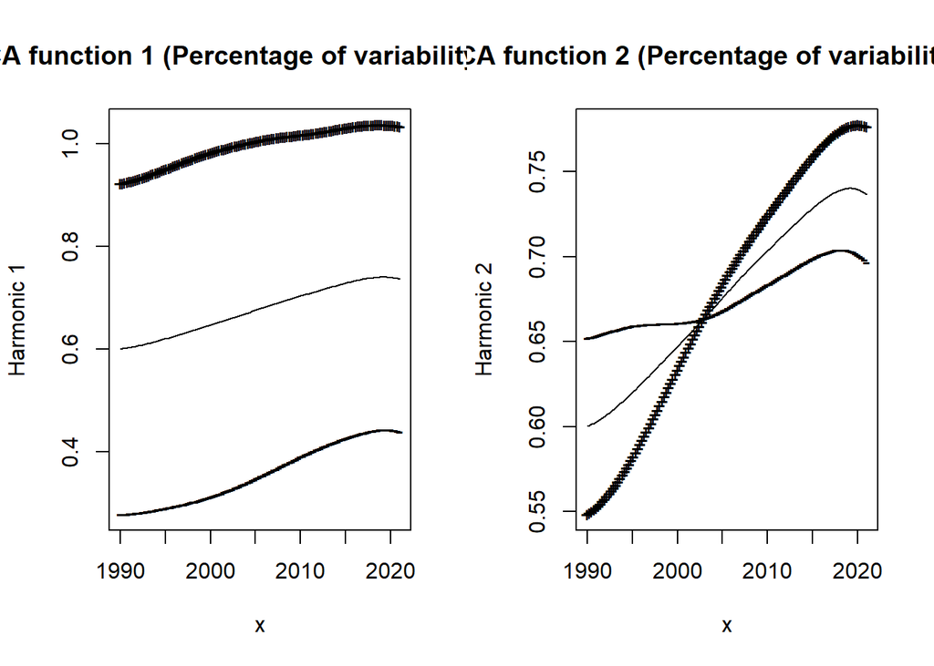

```r
fd_HDI_LL <- fdata2fd(HDI_LL)
fpcaHDIfd <- pca.fd(fd_HDI_LL)
par(mfrow=c(1,2))
plot(fpcaHDIfd)
```

```r
par(mfrow=c(1,1))
```

```r
fpcaHDI <- fdata2pc(HDI_LL)
summary(fpcaHDI)
```

```
## [1] TRUE
##
##      - SUMMARY:   fdata2pc  object   -
##
## -With 2  components are explained  99.6 %
##  of the variability of explicative variables.
##
## -Variability for each component (%):
## [1] 98.72  0.87
```

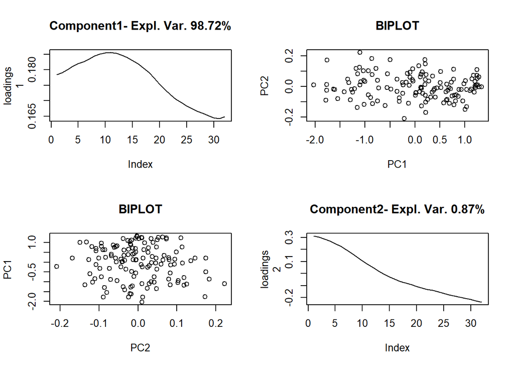

**3.5** Do the scatterplot of the scores on the first two principal functions, adding the country name to each point. Comment your results.

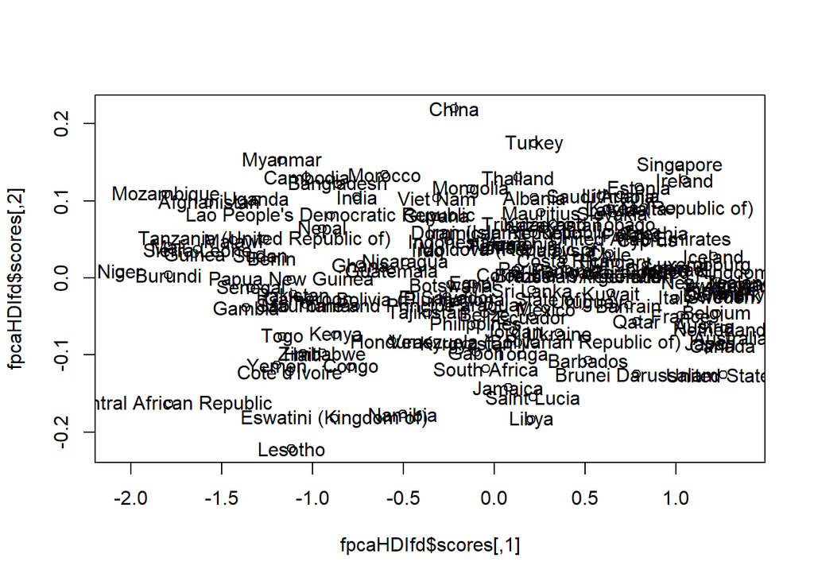

```r
plot(fpcaHDIfd$scores)
text(fpcaHDIfd$scores[,1], fpcaHDIfd$scores[,2],
     rownames(HDI_series))
```

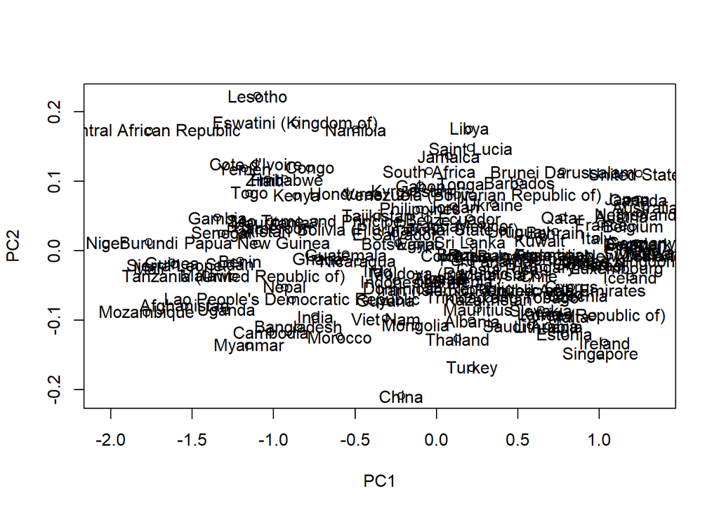

```r
plot(fpcaHDI$x)
text(fpcaHDI$x[,1], fpcaHDI$x[,2],
     rownames(HDI_series))
```

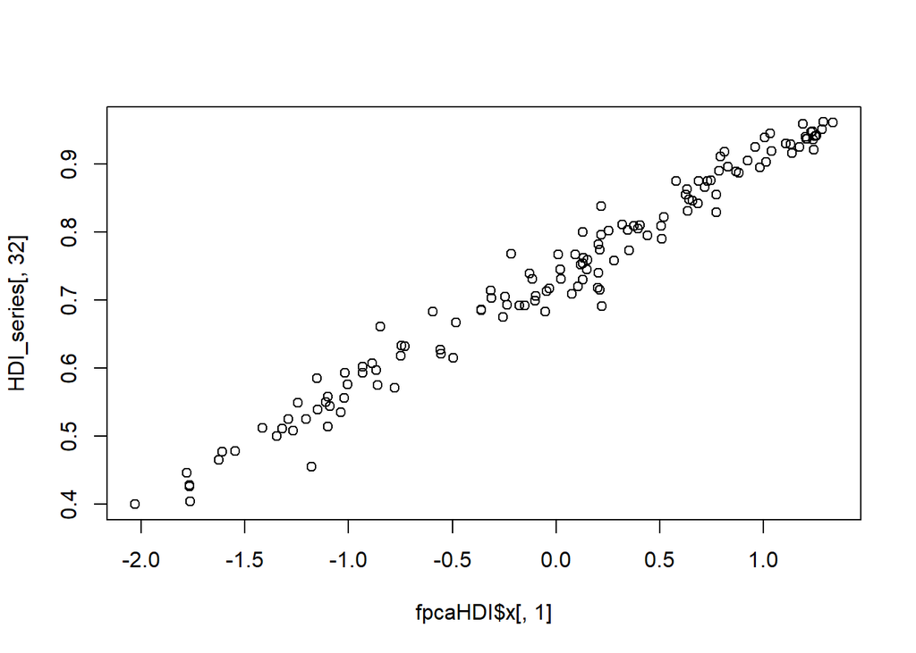

```r
# 1st FPC: Index of Human Development:
plot(fpcaHDI$x[,1],HDI_series[,32])
```

```r
#  Less developed countries: Niger, Mozambique, Burundi, Central African Republic, ...
#  Most developed countries: Norway, Switzerland, Sweden, Australia, USA, ...
# 2nd FPC: Speed of development growth:
# Most slow development: Leshoto, Libia, Eswatini, Namibia, Central African Republic, ...
# Most fast development: China, Turkey, Myanmar, Singapore, ...
```

## 4. Interpretable Machine Learning **(2 points out of 10)**

Consider the problem of predicting `HDI$HDI` from the rest of variables in the data frame `HDI`.

**4.1** Found the gam model you consider the *best one* to explain `HDI$HDI` from the rest of variables in the data frame `HDI`. Call if `gamHDI`.

```r
gam1 <- gam(HDI~
              s(Median_age) +
              s(Old_age_dep_rat) +
              s(Exp_years_school) +
              s(Life_expec) +
              s(Inf_Mort_rat) +
              s(log_GDP_per_cap,by=Continent) +
              s(Mob_phon_100_peopl) +
              s(Agric_employ_perc) +
              s(Servi_employ_perc) +
              s(Employment_rat) +
              Continent,
            data=HDI)
summary(gam1)
```

```
##
## Family: gaussian
## Link function: identity
##
## Formula:
## HDI ~ s(Median_age) + s(Old_age_dep_rat) + s(Exp_years_school) +
##     s(Life_expec) + s(Inf_Mort_rat) + s(log_GDP_per_cap, by = Continent) +
##     s(Mob_phon_100_peopl) + s(Agric_employ_perc) + s(Servi_employ_perc) +
##     s(Employment_rat) + Continent
##
## Parametric coefficients:
##                   Estimate Std. Error t value Pr(>|t|)
## (Intercept)       0.697861   0.005881 118.654  < 2e-16 ***
## ContinentAmericas 0.016781   0.008105   2.070  0.04050 *
## ContinentAsia     0.017712   0.006447   2.747  0.00691 **
## ContinentEurope   0.061876   0.033845   1.828  0.06993 .
## ContinentOceania  0.027330   0.010384   2.632  0.00957 **
## ---
## Signif. codes:  0 '***' 0.001 '**' 0.01 '*' 0.05 '.' 0.1 ' ' 1
##
## Approximate significance of smooth terms:
##                                        edf Ref.df       F  p-value
## s(Median_age)                        1.000  1.000   1.218  0.27193
## s(Old_age_dep_rat)                   2.008  2.526   4.749  0.00738 **
## s(Exp_years_school)                  3.678  4.722  34.522  < 2e-16 ***
## s(Life_expec)                        1.000  1.000  22.786 5.23e-06 ***
## s(Inf_Mort_rat)                      1.000  1.000   3.920  0.04993 *
## s(log_GDP_per_cap):ContinentAfrica   1.809  2.270 131.493  < 2e-16 ***
## s(log_GDP_per_cap):ContinentAmericas 2.284  2.836  52.200  < 2e-16 ***
## s(log_GDP_per_cap):ContinentAsia     1.568  1.936 137.342  < 2e-16 ***
## s(log_GDP_per_cap):ContinentEurope   4.791  5.460  15.456  < 2e-16 ***
## s(log_GDP_per_cap):ContinentOceania  1.000  1.000  70.917  < 2e-16 ***
## s(Mob_phon_100_peopl)                8.677  8.960   3.218  0.00104 **
## s(Agric_employ_perc)                 1.000  1.000   1.518  0.22032
## s(Servi_employ_perc)                 1.000  1.000   0.256  0.61386
## s(Employment_rat)                    5.572  6.676   1.622  0.15886
## ---
## Signif. codes:  0 '***' 0.001 '**' 0.01 '*' 0.05 '.' 0.1 ' ' 1
##
## R-sq.(adj) =  0.989   Deviance explained = 99.2%
## GCV = 0.00034524  Scale est. = 0.00025864  n = 165
```

```r
gam2 <- gam(HDI~
              s(Old_age_dep_rat) +
              s(Exp_years_school) +
              Life_expec +
              s(log_GDP_per_cap,by=Continent) +
              s(Mob_phon_100_peopl) +
              Agric_employ_perc*Continent +
              s(Employment_rat,by=Continent) +
              Continent,
            data=HDI)
summary(gam2)
```

```
##
## Family: gaussian
## Link function: identity
##
## Formula:
## HDI ~ s(Old_age_dep_rat) + s(Exp_years_school) + Life_expec +
##     s(log_GDP_per_cap, by = Continent) + s(Mob_phon_100_peopl) +
##     Agric_employ_perc * Continent + s(Employment_rat, by = Continent) +
##     Continent
##
## Parametric coefficients:
##                                       Estimate Std. Error t value Pr(>|t|)
## (Intercept)                          4.388e-01  2.848e-02  15.404  < 2e-16 ***
## Life_expec                           3.599e-03  3.917e-04   9.189 1.79e-15 ***
## Agric_employ_perc                   -4.878e-05  1.403e-04  -0.348 0.728686
## ContinentAmericas                    2.193e-02  1.418e-02   1.547 0.124618
## ContinentAsia                        4.096e-02  1.025e-02   3.996 0.000113 ***
## ContinentEurope                      6.268e-02  2.739e-02   2.288 0.023918 *
## ContinentOceania                     2.486e-02  1.465e-02   1.698 0.092257 .
## Agric_employ_perc:ContinentAmericas -1.324e-04  7.056e-04  -0.188 0.851482
## Agric_employ_perc:ContinentAsia     -7.763e-04  2.924e-04  -2.655 0.009041 **
## Agric_employ_perc:ContinentEurope    8.922e-05  6.109e-04   0.146 0.884136
## Agric_employ_perc:ContinentOceania   3.511e-04  4.705e-04   0.746 0.456962
## ---
## Signif. codes:  0 '***' 0.001 '**' 0.01 '*' 0.05 '.' 0.1 ' ' 1
##
## Approximate significance of smooth terms:
##                                        edf Ref.df       F  p-value
## s(Old_age_dep_rat)                   2.307  2.912   6.249 0.000624 ***
## s(Exp_years_school)                  3.792  4.859  48.554  < 2e-16 ***
## s(log_GDP_per_cap):ContinentAfrica   1.517  1.873 226.287  < 2e-16 ***
## s(log_GDP_per_cap):ContinentAmericas 2.435  3.009  20.831  < 2e-16 ***
## s(log_GDP_per_cap):ContinentAsia     1.001  1.002 108.228  < 2e-16 ***
## s(log_GDP_per_cap):ContinentEurope   4.165  4.891   9.907  < 2e-16 ***
## s(log_GDP_per_cap):ContinentOceania  1.000  1.000  50.901  < 2e-16 ***
## s(Mob_phon_100_peopl)                8.583  8.943   2.846 0.007766 **
## s(Employment_rat):ContinentAfrica    1.055  1.106   0.720 0.374869
## s(Employment_rat):ContinentAmericas  1.000  1.000   0.601 0.439637
## s(Employment_rat):ContinentAsia      8.286  8.828   3.376 0.000931 ***
## s(Employment_rat):ContinentEurope    1.000  1.000   5.102 0.025758 *
## s(Employment_rat):ContinentOceania   1.000  1.000   2.954 0.088298 .
## ---
## Signif. codes:  0 '***' 0.001 '**' 0.01 '*' 0.05 '.' 0.1 ' ' 1
##
## R-sq.(adj) =  0.991   Deviance explained = 99.3%
## GCV = 0.00030467  Scale est. = 0.00021577  n = 165
```

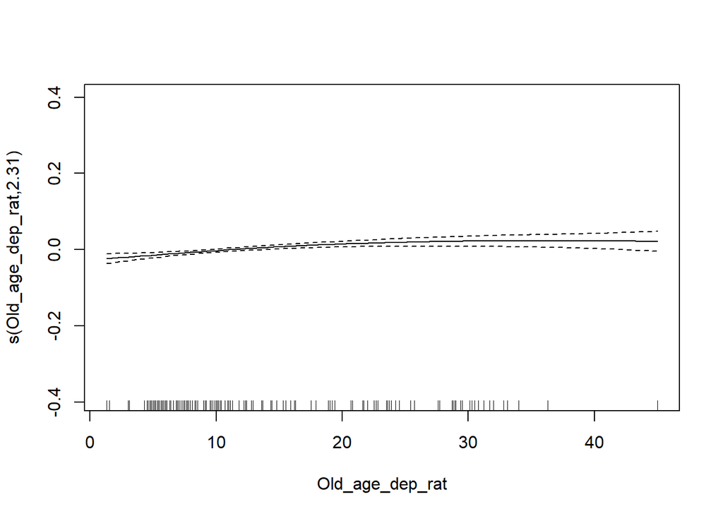

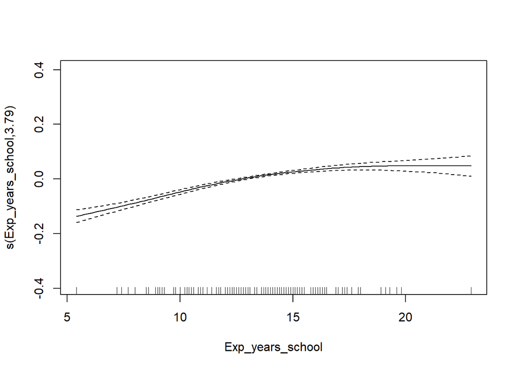

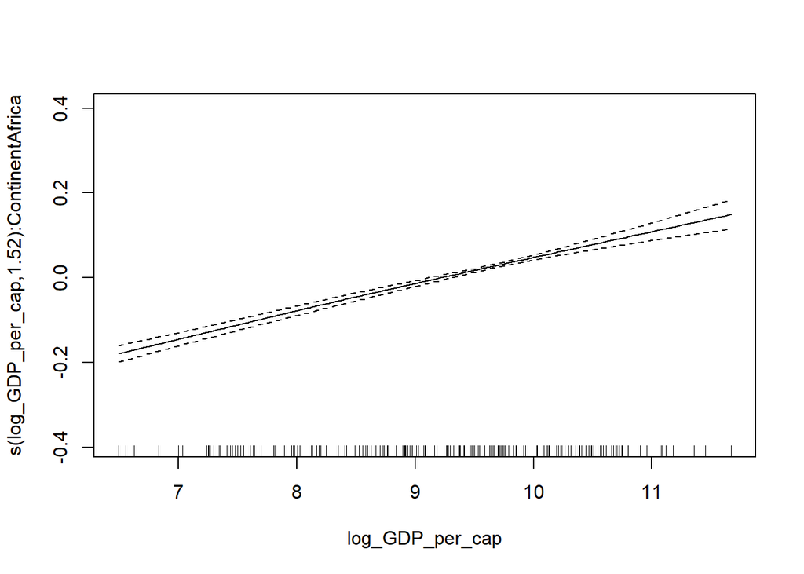

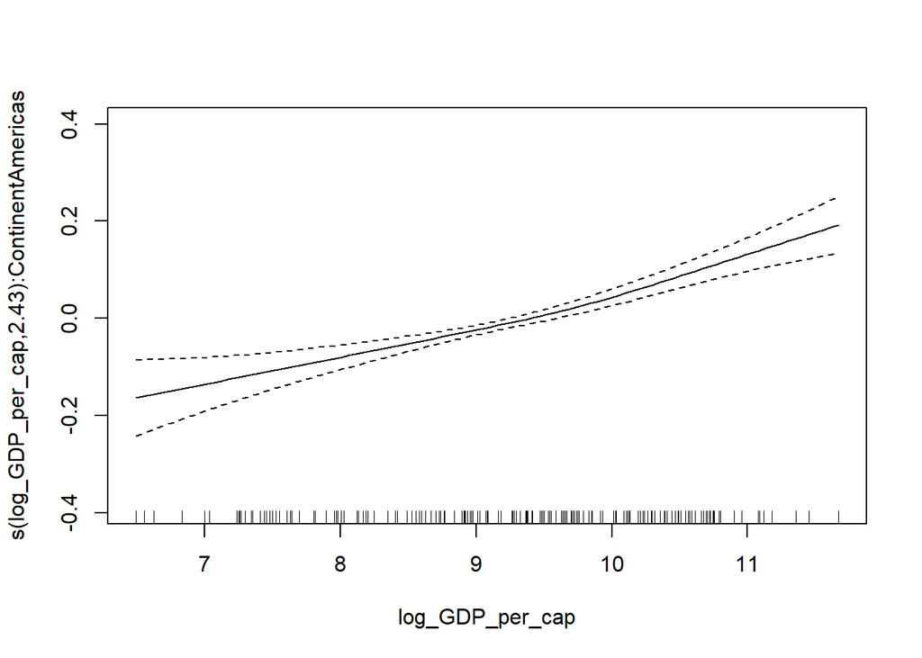

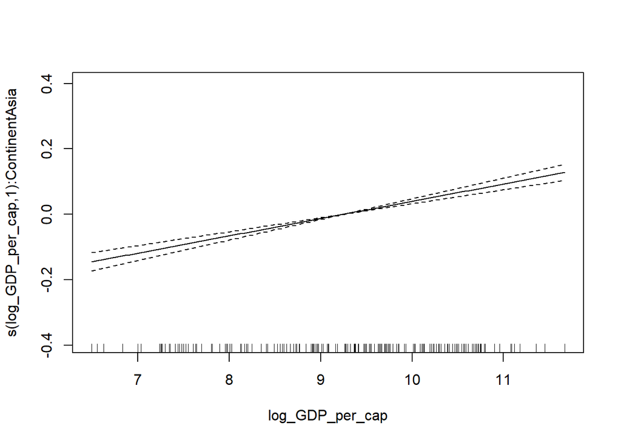

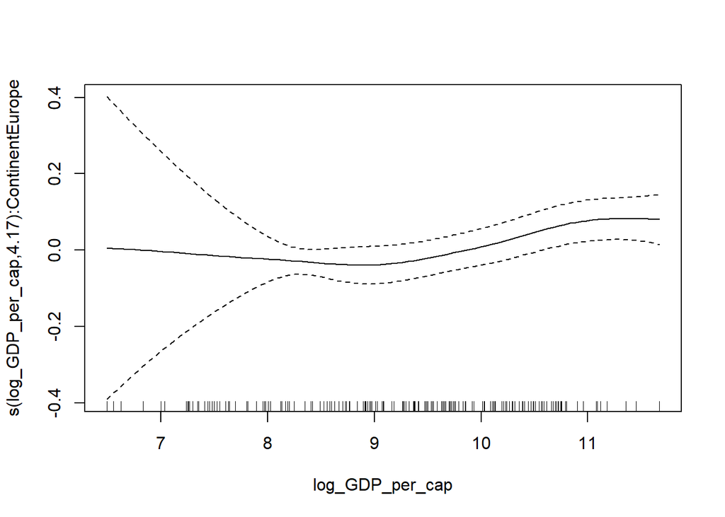

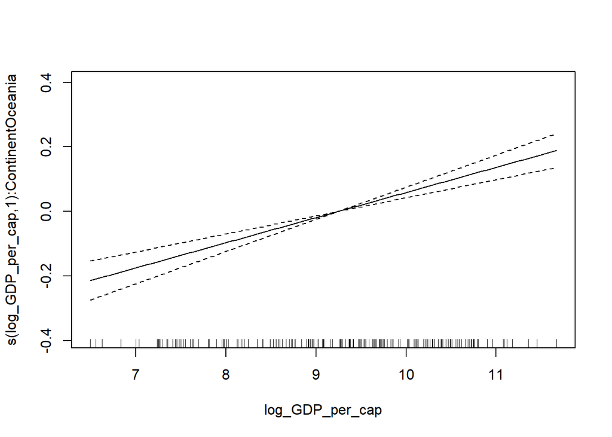

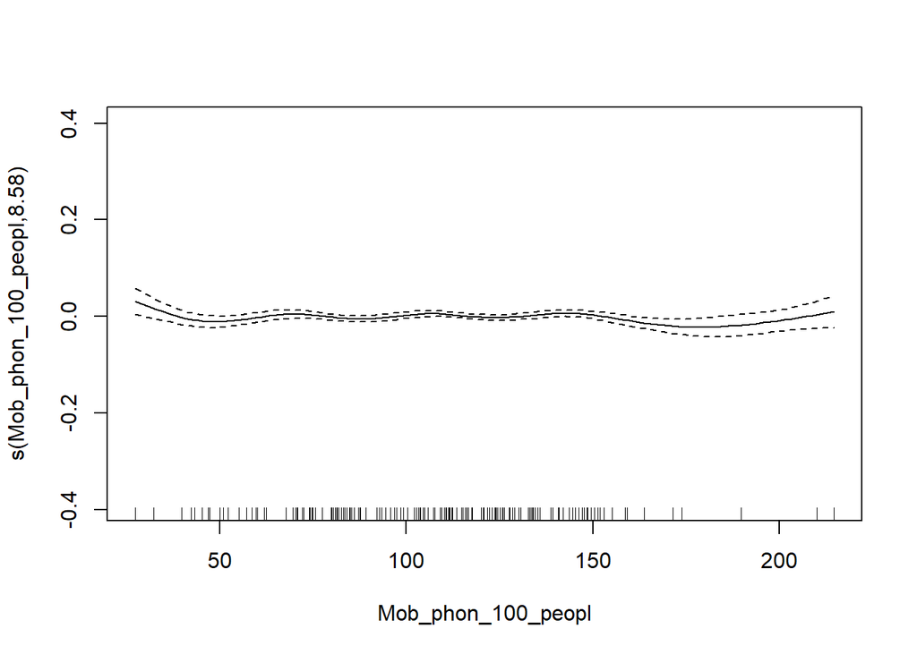

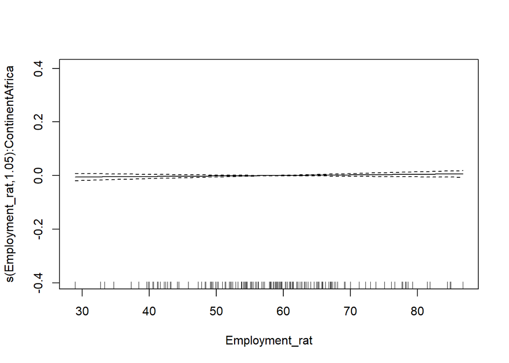

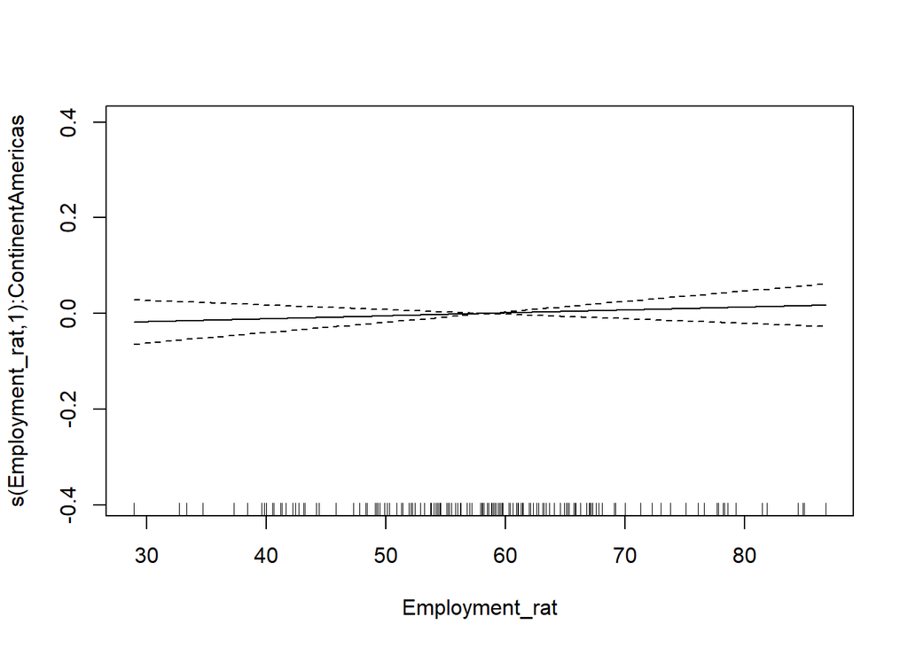

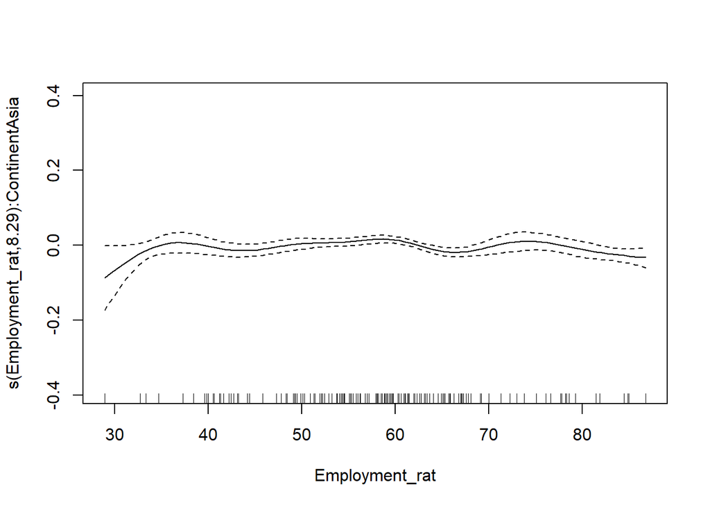

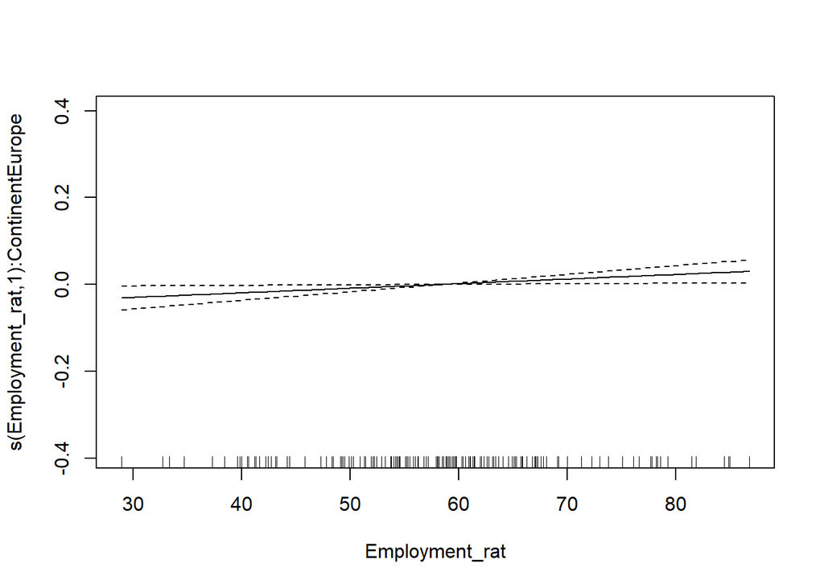

[1 more figures not shown]

```r
plot(gam2)
```

```r
gam3 <- gam(HDI~
              s(Old_age_dep_rat) +
              s(Exp_years_school) +
              Life_expec +
              s(log_GDP_per_cap) +
              Agric_employ_perc*Continent +
              s(Employment_rat,by=Continent) +
              Continent,
            data=HDI)
summary(gam3)
```

```
##
## Family: gaussian
## Link function: identity
##
## Formula:
## HDI ~ s(Old_age_dep_rat) + s(Exp_years_school) + Life_expec +
##     s(log_GDP_per_cap) + Agric_employ_perc * Continent + s(Employment_rat,
##     by = Continent) + Continent
##
## Parametric coefficients:
##                                       Estimate Std. Error t value Pr(>|t|)
## (Intercept)                          0.4561702  0.0294596  15.485  < 2e-16 ***
## Life_expec                           0.0034354  0.0004099   8.380 7.44e-14 ***
## Agric_employ_perc                   -0.0001945  0.0001337  -1.455  0.14806
## ContinentAmericas                    0.0141624  0.0094332   1.501  0.13569
## ContinentAsia                        0.0293056  0.0088546   3.310  0.00121 **
## ContinentEurope                      0.0158925  0.0111045   1.431  0.15478
## ContinentOceania                     0.0219362  0.0163960   1.338  0.18326
## Agric_employ_perc:ContinentAmericas -0.0002042  0.0003798  -0.538  0.59166
## Agric_employ_perc:ContinentAsia     -0.0003585  0.0002092  -1.714  0.08896 .
## Agric_employ_perc:ContinentEurope    0.0008307  0.0004518   1.838  0.06827 .
## Agric_employ_perc:ContinentOceania   0.0002767  0.0003451   0.802  0.42413
## ---
## Signif. codes:  0 '***' 0.001 '**' 0.01 '*' 0.05 '.' 0.1 ' ' 1
##
## Approximate significance of smooth terms:
##                                       edf Ref.df       F  p-value
## s(Old_age_dep_rat)                  2.803  3.571   8.255 2.01e-05 ***
## s(Exp_years_school)                 5.666  6.887  29.292  < 2e-16 ***
## s(log_GDP_per_cap)                  1.000  1.000 474.810  < 2e-16 ***
## s(Employment_rat):ContinentAfrica   1.594  1.963   0.703 0.448820
## s(Employment_rat):ContinentAmericas 1.000  1.000   1.644 0.202068
## s(Employment_rat):ContinentAsia     8.709  8.967   3.940 0.000198 ***
## s(Employment_rat):ContinentEurope   1.000  1.000   5.356 0.022213 *
## s(Employment_rat):ContinentOceania  2.129  2.412   1.602 0.111815
## ---
## Signif. codes:  0 '***' 0.001 '**' 0.01 '*' 0.05 '.' 0.1 ' ' 1
##
## R-sq.(adj) =  0.989   Deviance explained = 99.1%
## GCV = 0.00032122  Scale est. = 0.00025328  n = 165
```

```r
anova(gam3,gam2,test="F")
```

```
## Analysis of Deviance Table
##
## Model 1: HDI ~ s(Old_age_dep_rat) + s(Exp_years_school) + Life_expec +
##     s(log_GDP_per_cap) + Agric_employ_perc * Continent + s(Employment_rat,
##     by = Continent) + Continent
## Model 2: HDI ~ s(Old_age_dep_rat) + s(Exp_years_school) + Life_expec +
##     s(log_GDP_per_cap, by = Continent) + s(Mob_phon_100_peopl) +
##     Agric_employ_perc * Continent + s(Employment_rat, by = Continent) +
##     Continent
##   Resid. Df Resid. Dev     Df  Deviance      F   Pr(>F)
## 1    127.20   0.032951
## 2    112.58   0.025215 14.623 0.0077364 2.4519 0.004169 **
## ---
## Signif. codes:  0 '***' 0.001 '**' 0.01 '*' 0.05 '.' 0.1 ' ' 1
```

```r
gam4 <- gam(HDI~
              s(Old_age_dep_rat) +
              s(Exp_years_school) +
              Life_expec +
              s(log_GDP_per_cap) +
              Continent,
            data=HDI)
summary(gam4)
```

```
##
## Family: gaussian
## Link function: identity
##
## Formula:
## HDI ~ s(Old_age_dep_rat) + s(Exp_years_school) + Life_expec +
##     s(log_GDP_per_cap) + Continent
##
## Parametric coefficients:
##                    Estimate Std. Error t value Pr(>|t|)
## (Intercept)       0.4306394  0.0304515  14.142  < 2e-16 ***
## Life_expec        0.0037510  0.0004385   8.555 1.37e-14 ***
## ContinentAmericas 0.0116028  0.0057576   2.015  0.04569 *
## ContinentAsia     0.0142319  0.0050011   2.846  0.00506 **
## ContinentEurope   0.0152550  0.0077216   1.976  0.05006 .
## ContinentOceania  0.0195019  0.0081272   2.400  0.01766 *
## ---
## Signif. codes:  0 '***' 0.001 '**' 0.01 '*' 0.05 '.' 0.1 ' ' 1
##
## Approximate significance of smooth terms:
##                       edf Ref.df      F  p-value
## s(Old_age_dep_rat)  2.212  2.818   6.22 0.000952 ***
## s(Exp_years_school) 3.344  4.296  45.90  < 2e-16 ***
## s(log_GDP_per_cap)  5.447  6.618 104.53  < 2e-16 ***
## ---
## Signif. codes:  0 '***' 0.001 '**' 0.01 '*' 0.05 '.' 0.1 ' ' 1
##
## R-sq.(adj) =  0.986   Deviance explained = 98.7%
## GCV = 0.00036527  Scale est. = 0.00032763  n = 165
```

```r
gamHDI <- gam4
```

**4.2** Fit a random forest to explain `HDI$HDI` from the rest of variables in the data frame `HDI`. Call if `rfHDI`.

```r
library(ranger)
library(randomForest)
library(caret)
library(vip)
library(DALEX)
library(DALEXtra)
library(lime)
library(iml)
library(localModel)
# library(fastshap) # Attention! It re-define "explain" from DALEX
```

```r
rfHDI <- ranger(
  HDI ~ .,
  data = HDI,
  importance='impurity'
)
print(rfHDI)
```

```
## Ranger result
##
## Call:
##  ranger(HDI ~ ., data = HDI, importance = "impurity")
##
## Type:                             Regression
## Number of trees:                  500
## Sample size:                      165
## Number of independent variables:  11
## Mtry:                             3
## Target node size:                 5
## Variable importance mode:         impurity
## Splitrule:                        variance
## OOB prediction error (MSE):       0.0006932373
## R squared (OOB):                  0.9704701
```

**4.3** Compute the relevance of each explanatory variable by Shapley values at both models, `gamHDI` and `rfHDI`. Comment your results.

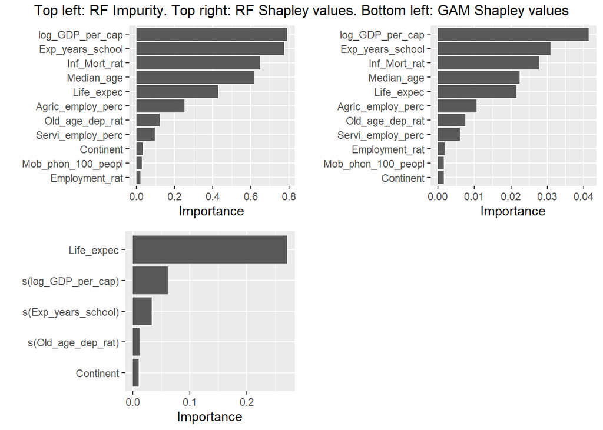

```r
rf_imp <- vip(rfHDI, num_features = 11)
rf_shapley <- vip(rfHDI, method="shap",
                  pred_wrapper=yhat, num_features = 11,
                  newdata=HDI[,-1]) # Package "fastshap" needed for this function to work
gam_shapley <- vip(gamHDI, method="shap",
                  pred_wrapper=predict.gam,
                  num_features = 11,
                  newdata=HDI[,-1],
                  exact=TRUE) # Package "fastshap" needed for this function to work

grid.arrange(rf_imp, rf_shapley, gam_shapley,
             ncol=2, nrow=2,
             top="Top left: RF Impurity. Top right: RF Shapley values. Bottom left: GAM Shapley values"
            )
```

**4.4** Consider these two countries: Spain and Qatar. For each of them, provide local explanations for the predicted values when using the random forest `rfHDI` (choose the explanatory methods that you consider most appropriate.) Comment your results.

```r
# Using library DALEX
# help(package="DALEX")
# ? explain
explainer_rf <- explain.default(model = rfHDI, data = HDI[, -1], y = HDI[,1],
                               label = "Random Forest")
```

```
## Preparation of a new explainer is initiated
##   -> model label       :  Random Forest
##   -> data              :  165  rows  11  cols
##   -> target variable   :  165  values
##   -> predict function  :  yhat.ranger  will be used (  default  )
##   -> predicted values  :  No value for predict function target column. (  default  )
##   -> model_info        :  package ranger , ver. 0.13.1 , task regression (  default  )
##   -> predicted values  :  numerical, min =  0.3974959 , mean =  0.7119482 , max =  0.9404447
##   -> residual function :  difference between y and yhat (  default  )
##   -> residuals         :  numerical, min =  -0.0463408 , mean =  -0.0005421679 , max =  0.02588323
##   A new explainer has been created!
```

```r
aux <- which(country=="Spain")
(Spain <- HDI[aux,])
```

```
##         HDI Median_age Old_age_dep_rat Exp_years_school Life_expec Inf_Mort_rat
## Spain 0.891       43.2            29.5             17.9       83.3          2.7
##       log_GDP_per_cap Mob_phon_100_peopl Agric_employ_perc Servi_employ_perc
## Spain        10.44208              111.2               4.1              76.4
##       Employment_rat Continent
## Spain           47.8    Europe
```

```r
aux <- which(country=="Qatar")
(Qatar <- HDI[aux,])
```

```
##         HDI Median_age Old_age_dep_rat Exp_years_school Life_expec Inf_Mort_rat
## Qatar 0.856       31.3             1.5             13.4       78.3          7.3
##       log_GDP_per_cap Mob_phon_100_peopl Agric_employ_perc Servi_employ_perc
## Qatar        11.66938              142.1               1.3              43.6
##       Employment_rat Continent
## Qatar           86.8      Asia
```

```r
## SHAP
bd_rf <- predict_parts(explainer = explainer_rf,
                 new_observation = Spain,
                            type = "shap")

bd_rf
```

```
##                                                     min            q1
## Random Forest: Agric_employ_perc = 4.1     0.0079386220  0.0098079440
## Random Forest: Continent = Europe          0.0001656149  0.0006337903
## Random Forest: Employment_rat = 47.8      -0.0076765828 -0.0044202281
## Random Forest: Exp_years_school = 17.9     0.0300637145  0.0330848839
## Random Forest: Inf_Mort_rat = 2.7          0.0294980701  0.0335292029
## Random Forest: Life_expec = 83.3           0.0227143533  0.0253261969
## Random Forest: log_GDP_per_cap = 10.44     0.0369425477  0.0411125555
## Random Forest: Median_age = 43.2           0.0200993055  0.0209799523
## Random Forest: Mob_phon_100_peopl = 111.2 -0.0002991224  0.0004555407
## Random Forest: Old_age_dep_rat = 29.5      0.0077586077  0.0087824587
## Random Forest: Servi_employ_perc = 76.4    0.0041193471  0.0055211820
##                                                  median          mean
## Random Forest: Agric_employ_perc = 4.1     0.0119476455  0.0109739343
## Random Forest: Continent = Europe          0.0012815857  0.0012051229
## Random Forest: Employment_rat = 47.8      -0.0017598602 -0.0031053899
## Random Forest: Exp_years_school = 17.9     0.0341172165  0.0339912437
## Random Forest: Inf_Mort_rat = 2.7          0.0341518997  0.0339823749
## Random Forest: Life_expec = 83.3           0.0266864255  0.0263599714
## Random Forest: log_GDP_per_cap = 10.44     0.0432449084  0.0428259826
## Random Forest: Median_age = 43.2           0.0225190978  0.0228523357
## Random Forest: Mob_phon_100_peopl = 111.2  0.0006950069  0.0005855631
## Random Forest: Old_age_dep_rat = 29.5      0.0092302813  0.0092479645
## Random Forest: Servi_employ_perc = 76.4    0.0065969419  0.0064962016
##                                                      q3          max
## Random Forest: Agric_employ_perc = 4.1     0.0121716937  0.014652644
## Random Forest: Continent = Europe          0.0014570210  0.002671636
## Random Forest: Employment_rat = 47.8      -0.0010892497 -0.001046572
## Random Forest: Exp_years_school = 17.9     0.0352590796  0.038608877
## Random Forest: Inf_Mort_rat = 2.7          0.0355647188  0.036996128
## Random Forest: Life_expec = 83.3           0.0278780362  0.028832912
## Random Forest: log_GDP_per_cap = 10.44     0.0446333004  0.048697128
## Random Forest: Median_age = 43.2           0.0243225327  0.026611455
## Random Forest: Mob_phon_100_peopl = 111.2  0.0008481603  0.001130544
## Random Forest: Old_age_dep_rat = 29.5      0.0096528081  0.011160293
## Random Forest: Servi_employ_perc = 76.4    0.0073046842  0.008867365
```

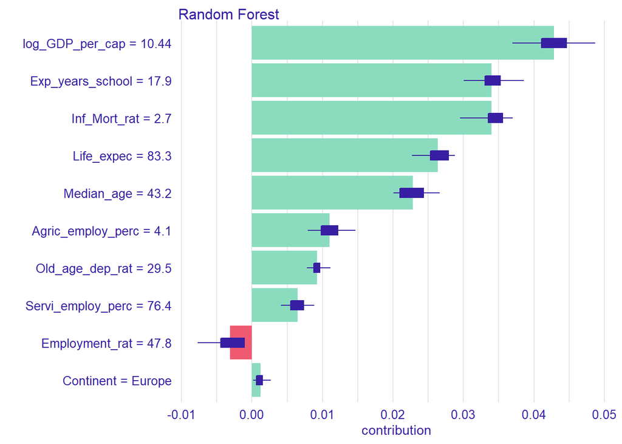

```r
plot(bd_rf)
```

```r
bd_rf <- predict_parts(explainer = explainer_rf,
                 new_observation = Qatar,
                            type = "shap")

bd_rf
```

```
##                                                     min            q1
## Random Forest: Agric_employ_perc = 1.3     0.0097451970  0.0102194743
## Random Forest: Continent = Asia            0.0004302556  0.0007766284
## Random Forest: Employment_rat = 86.8      -0.0016145513 -0.0006381962
## Random Forest: Exp_years_school = 13.4     0.0137254541  0.0151168032
## Random Forest: Inf_Mort_rat = 7.3          0.0133724471  0.0150564626
## Random Forest: Life_expec = 78.3           0.0127667560  0.0132344370
## Random Forest: log_GDP_per_cap = 11.67     0.0412526576  0.0464661446
## Random Forest: Median_age = 31.3           0.0168307578  0.0185966451
## Random Forest: Mob_phon_100_peopl = 142.1  0.0009667998  0.0012931375
## Random Forest: Old_age_dep_rat = 1.5      -0.0059919440 -0.0037443058
## Random Forest: Servi_employ_perc = 43.6   -0.0030164255 -0.0023252655
##                                                  median          mean
## Random Forest: Agric_employ_perc = 1.3     0.0146312207  0.0143038392
## Random Forest: Continent = Asia            0.0009743666  0.0009791304
## Random Forest: Employment_rat = 86.8       0.0002690567  0.0004244902
## Random Forest: Exp_years_school = 13.4     0.0172280924  0.0166698623
## Random Forest: Inf_Mort_rat = 7.3          0.0165309269  0.0164882289
## Random Forest: Life_expec = 78.3           0.0150591671  0.0149823442
## Random Forest: log_GDP_per_cap = 11.67     0.0478590631  0.0488173772
## Random Forest: Median_age = 31.3           0.0216758493  0.0210791533
## Random Forest: Mob_phon_100_peopl = 142.1  0.0015393140  0.0016723906
## Random Forest: Old_age_dep_rat = 1.5      -0.0022829296 -0.0023940591
## Random Forest: Servi_employ_perc = 43.6   -0.0018937851 -0.0019724523
##                                                     q3          max
## Random Forest: Agric_employ_perc = 1.3     0.017513800  0.020796711
## Random Forest: Continent = Asia            0.001228620  0.001570777
## Random Forest: Employment_rat = 86.8       0.001297822  0.002633462
## Random Forest: Exp_years_school = 13.4     0.018037844  0.019010515
## Random Forest: Inf_Mort_rat = 7.3          0.017702954  0.018870456
## Random Forest: Life_expec = 78.3           0.016201436  0.017915719
## Random Forest: log_GDP_per_cap = 11.67     0.053792840  0.056275568
## Random Forest: Median_age = 31.3           0.023711749  0.025054311
## Random Forest: Mob_phon_100_peopl = 142.1  0.001961415  0.002809902
## Random Forest: Old_age_dep_rat = 1.5      -0.001053119  0.001753371
## Random Forest: Servi_employ_perc = 43.6   -0.001394045 -0.001010737
```

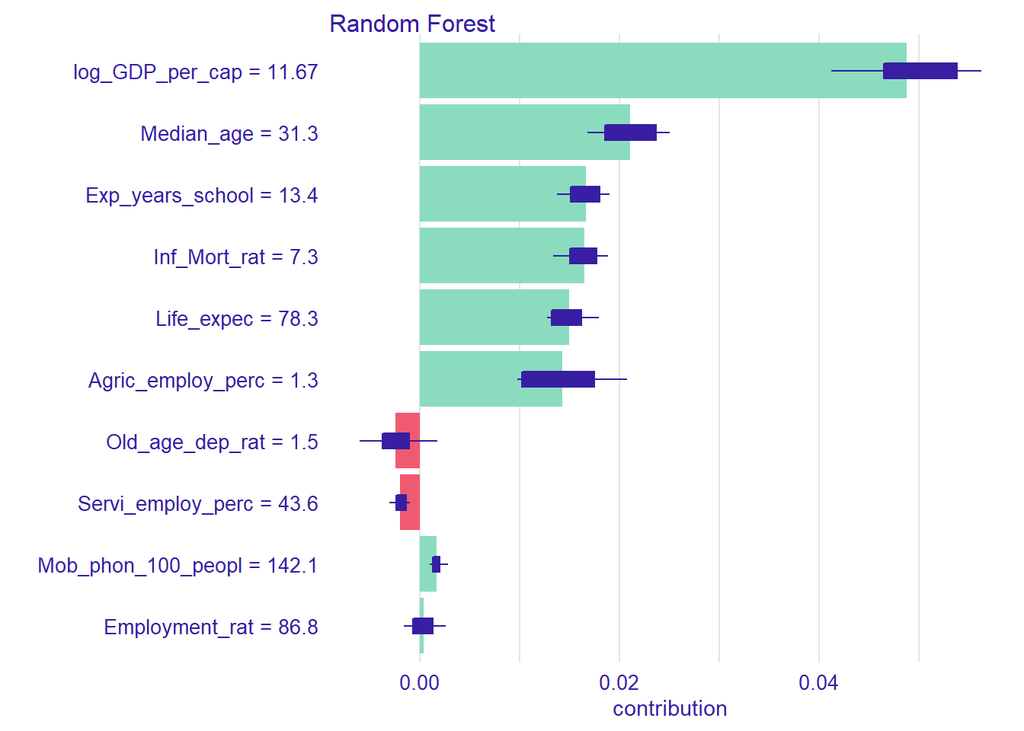

```r
plot(bd_rf)
```

```r
## Break-down plots
bd_rf <- predict_parts(explainer = explainer_rf,
                 new_observation = Spain,
                            type = "break_down")

bd_rf
```

```
##                                           contribution
## Random Forest: intercept                         0.712
## Random Forest: log_GDP_per_cap = 10.44           0.037
## Random Forest: Exp_years_school = 17.9           0.036
## Random Forest: Inf_Mort_rat = 2.7                0.035
## Random Forest: Life_expec = 83.3                 0.029
## Random Forest: Median_age = 43.2                 0.024
## Random Forest: Old_age_dep_rat = 29.5            0.010
## Random Forest: Agric_employ_perc = 4.1           0.014
## Random Forest: Servi_employ_perc = 76.4          0.009
## Random Forest: Continent = Europe                0.001
## Random Forest: Employment_rat = 47.8            -0.008
## Random Forest: Mob_phon_100_peopl = 111.2        0.000
## Random Forest: prediction                        0.897
```

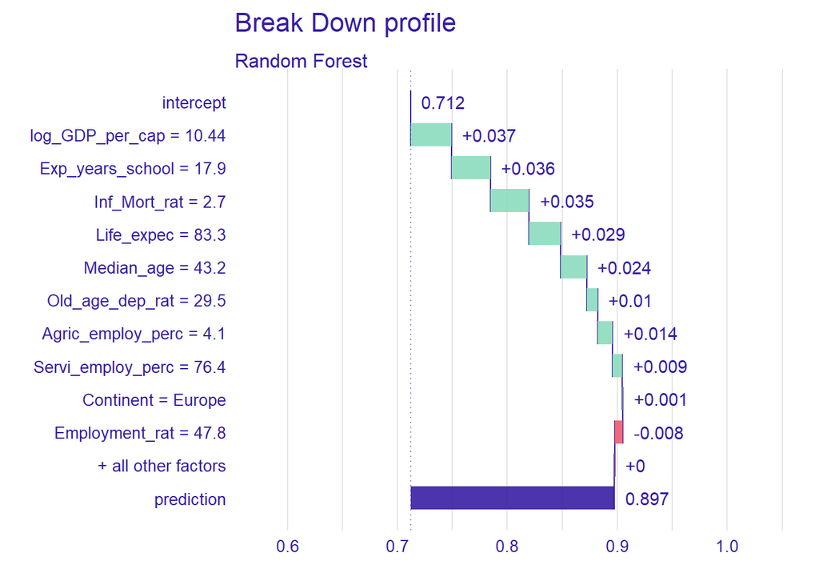

```r
plot(bd_rf)
```

```r
bd_rf <- predict_parts(explainer = explainer_rf,
                 new_observation = Qatar,
                            type = "break_down")

bd_rf
```

```
##                                           contribution
## Random Forest: intercept                         0.712
## Random Forest: log_GDP_per_cap = 11.67           0.041
## Random Forest: Median_age = 31.3                 0.022
## Random Forest: Inf_Mort_rat = 7.3                0.015
## Random Forest: Exp_years_school = 13.4           0.015
## Random Forest: Life_expec = 78.3                 0.014
## Random Forest: Agric_employ_perc = 1.3           0.019
## Random Forest: Old_age_dep_rat = 1.5             0.000
## Random Forest: Servi_employ_perc = 43.6         -0.002
## Random Forest: Mob_phon_100_peopl = 142.1        0.003
## Random Forest: Continent = Asia                  0.001
## Random Forest: Employment_rat = 86.8             0.003
## Random Forest: prediction                        0.843
```

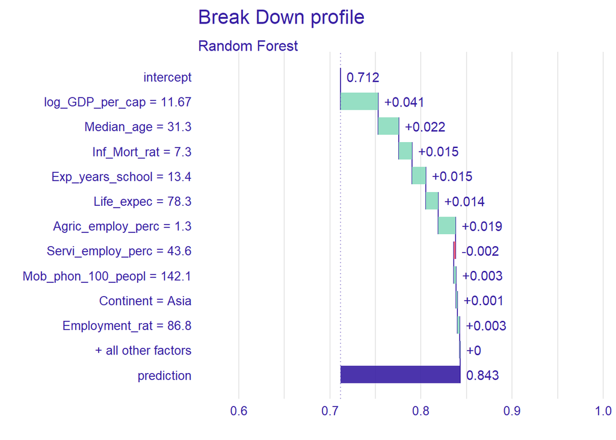

```r
plot(bd_rf)
```

## LIME

```r
lime_rf <- predict_surrogate(explainer = explainer_rf,
                  new_observation = Spain[,-1],
                  type = "localModel")
                  #type = "iml") # it does not work
                  #n_features = 6,
                  #n_permutations = 1000,
                  #type = "lime") # it does not work

lime_rf
```

```
##     estimated                variable original_variable dev_ratio response
## 1 0.711948228            (Model mean)                   0.6754158
## 2 0.665462831             (Intercept)                   0.6754158
## 3 0.033856173       Median_age > 28.4        Median_age 0.6754158
## 4 0.006205828 Old_age_dep_rat > 16.83   Old_age_dep_rat 0.6754158
## 5 0.038134633 Exp_years_school > 15.5  Exp_years_school 0.6754158
## 6 0.028289077      Life_expec > 80.08        Life_expec 0.6754158
##   predicted_value         model
## 1       0.8973635 Random Forest
## 2       0.8973635 Random Forest
## 3       0.8973635 Random Forest
## 4       0.8973635 Random Forest
## 5       0.8973635 Random Forest
## 6       0.8973635 Random Forest
```

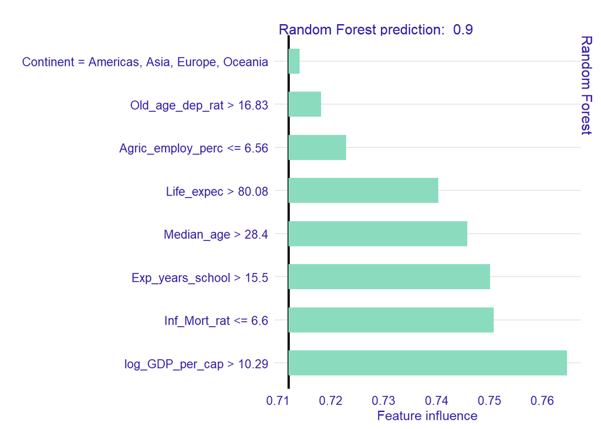

```r
plot(lime_rf)
```

```r
lime_rf <- predict_surrogate(explainer = explainer_rf,
                  new_observation = Qatar[,-1],
                  type = "localModel")
                  #type = "iml") # it does not work
                  #n_features = 6,
                  #n_permutations = 1000,
                  #type = "lime") # it does not work

lime_rf
```

```
##      estimated                         variable original_variable dev_ratio
## 1  0.711948228                     (Model mean)                   0.5697657
## 2  0.661547924                      (Intercept)                   0.5697657
## 3  0.036984717                Median_age > 28.4        Median_age 0.5697657
## 4 -0.003924402           Old_age_dep_rat <= 6.9   Old_age_dep_rat 0.5697657
## 5  0.016078796 12.62 < Exp_years_school <= 15.5  Exp_years_school 0.5697657
## 6  0.015889215                Life_expec > 77.8        Life_expec 0.5697657
##   response predicted_value         model
## 1                0.8429985 Random Forest
## 2                0.8429985 Random Forest
## 3                0.8429985 Random Forest
## 4                0.8429985 Random Forest
## 5                0.8429985 Random Forest
## 6                0.8429985 Random Forest
```

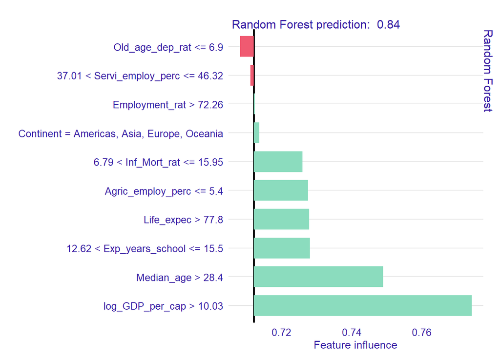

```r
plot(lime_rf)
```

```r
## Local Graphics
### Individual conditional expectation (ICE) plot, or ceteris paribus plot

cp_rf <- predict_profile(explainer = explainer_rf,
                           new_observation = Spain)
cp_rf
```

```
## Top profiles    :
##         Median_age Old_age_dep_rat Exp_years_school Life_expec Inf_Mort_rat
## Spain       14.900            29.5             17.9       83.3          2.7
## Spain.1     15.214            29.5             17.9       83.3          2.7
## Spain.2     15.528            29.5             17.9       83.3          2.7
## Spain.3     15.842            29.5             17.9       83.3          2.7
## Spain.4     16.156            29.5             17.9       83.3          2.7
## Spain.5     16.470            29.5             17.9       83.3          2.7
##         log_GDP_per_cap Mob_phon_100_peopl Agric_employ_perc Servi_employ_perc
## Spain          10.44208              111.2               4.1              76.4
## Spain.1        10.44208              111.2               4.1              76.4
## Spain.2        10.44208              111.2               4.1              76.4
## Spain.3        10.44208              111.2               4.1              76.4
## Spain.4        10.44208              111.2               4.1              76.4
## Spain.5        10.44208              111.2               4.1              76.4
##         Employment_rat Continent    _yhat_    _vname_ _ids_       _label_
## Spain             47.8    Europe 0.8481352 Median_age Spain Random Forest
## Spain.1           47.8    Europe 0.8481352 Median_age Spain Random Forest
## Spain.2           47.8    Europe 0.8484912 Median_age Spain Random Forest
## Spain.3           47.8    Europe 0.8484912 Median_age Spain Random Forest
## Spain.4           47.8    Europe 0.8484912 Median_age Spain Random Forest
## Spain.5           47.8    Europe 0.8484912 Median_age Spain Random Forest
##
##
## Top observations:
##       Median_age Old_age_dep_rat Exp_years_school Life_expec Inf_Mort_rat
## Spain       43.2            29.5             17.9       83.3          2.7
##       log_GDP_per_cap Mob_phon_100_peopl Agric_employ_perc Servi_employ_perc
## Spain        10.44208              111.2               4.1              76.4
##       Employment_rat Continent    _yhat_       _label_ _ids_
## Spain           47.8    Europe 0.8973635 Random Forest     1
```

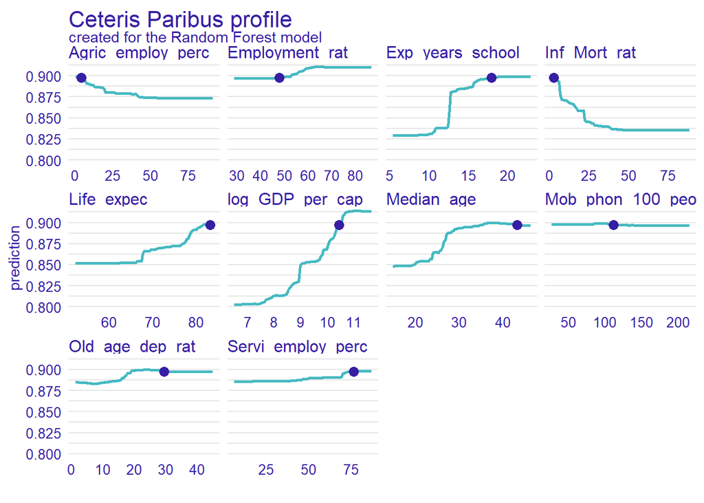

```r
plot(cp_rf)
```

```r
cp_rf <- predict_profile(explainer = explainer_rf,
                           new_observation = Qatar)
cp_rf
```

```
## Top profiles    :
##         Median_age Old_age_dep_rat Exp_years_school Life_expec Inf_Mort_rat
## Qatar       14.900             1.5             13.4       78.3          7.3
## Qatar.1     15.214             1.5             13.4       78.3          7.3
## Qatar.2     15.528             1.5             13.4       78.3          7.3
## Qatar.3     15.842             1.5             13.4       78.3          7.3
## Qatar.4     16.156             1.5             13.4       78.3          7.3
## Qatar.5     16.470             1.5             13.4       78.3          7.3
##         log_GDP_per_cap Mob_phon_100_peopl Agric_employ_perc Servi_employ_perc
## Qatar          11.66938              142.1               1.3              43.6
## Qatar.1        11.66938              142.1               1.3              43.6
## Qatar.2        11.66938              142.1               1.3              43.6
## Qatar.3        11.66938              142.1               1.3              43.6
## Qatar.4        11.66938              142.1               1.3              43.6
## Qatar.5        11.66938              142.1               1.3              43.6
##         Employment_rat Continent    _yhat_    _vname_ _ids_       _label_
## Qatar             86.8      Asia 0.7840018 Median_age Qatar Random Forest
## Qatar.1           86.8      Asia 0.7840018 Median_age Qatar Random Forest
## Qatar.2           86.8      Asia 0.7843578 Median_age Qatar Random Forest
## Qatar.3           86.8      Asia 0.7843578 Median_age Qatar Random Forest
## Qatar.4           86.8      Asia 0.7843578 Median_age Qatar Random Forest
## Qatar.5           86.8      Asia 0.7843578 Median_age Qatar Random Forest
##
##
## Top observations:
##       Median_age Old_age_dep_rat Exp_years_school Life_expec Inf_Mort_rat
## Qatar       31.3             1.5             13.4       78.3          7.3
##       log_GDP_per_cap Mob_phon_100_peopl Agric_employ_perc Servi_employ_perc
## Qatar        11.66938              142.1               1.3              43.6
##       Employment_rat Continent    _yhat_       _label_ _ids_
## Qatar           86.8      Asia 0.8429985 Random Forest     1
```

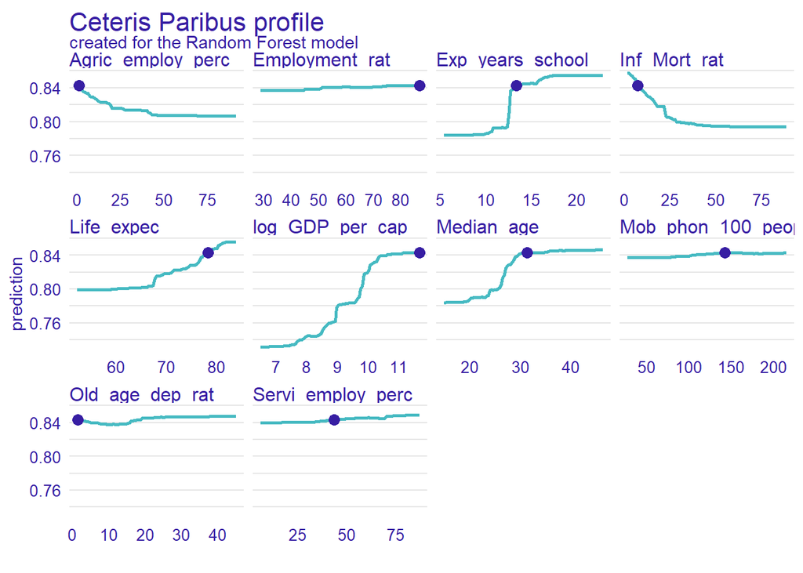

```r
plot(cp_rf)
```